# presentation

[figure not shown]

Reproducible Analytical Pipelines

[👤](https://ondrejmottl.github.io/) Ondřej Mottl

Science School on Quantitative Ecology 2026

bit.ly/SSoQE

## Reproducible analytical pipeline

[figure not shown]

[Illustration: Scriberia for The Turing Way, CC BY 4.0](https://zenodo.org/records/3332807)

## What we’ll cover today

### 🎯 **Main topics**

- Dependencies in an analysis
- A `{targets}` project
- Selective rebuilding
- Debugging and extension

### ✅ **By the end, you’ll be able to:**

- Create a `{targets}` project in RStudio
- Turn prepared functions into a pipeline
- Inspect, build, and retrieve targets
- Predict what becomes outdated after a change
- Add a new target to an existing pipeline

## A classic multi-script project

```
.
├─ Data/
│  ├─ Input/penguins.csv
│  └─ Processed/
│     ├─ penguins.rds
│     └─ model.rds
├─ R/
│  ├─ 00_master.R
│  ├─ 01_prepare_data.R
│  ├─ 02_fit_model.R
│  └─ 03_plot_results.R
└─ Outputs/penguin_figure.png
```

### `00_master.R`

```r
source("R/01_prepare_data.R")
source("R/02_fit_model.R")
source("R/03_plot_results.R")
```

The master script remembers the order.

Which stored results are outdated after one function changes?

## Three scripts, one analysis

### 1. Prepare

```r
# 01_prepare_data.R
penguins_species <-
  read_penguins(
    here::here(
      "Data", "Input",
      "penguins.csv"
    )
  ) |>
  clean_penguins() |>
  filter_penguins("Adelie")

readr::write_rds(
  penguins_species,
  here::here(
    "Data", "Processed",
    "penguins.rds"
  )
)
```

### 2. Model

```r
# 02_fit_model.R
penguins_species <-
  readr::read_rds(
    here::here(
      "Data", "Processed",
      "penguins.rds"
    )
  )

penguin_model <-
  fit_penguin_model(
    penguins_species
  )

readr::write_rds(
  penguin_model,
  here::here(
    "Data", "Processed",
    "model.rds"
  )
)
```

### 3. Plot

```r
# 03_plot_results.R
penguins_species <-
  readr::read_rds(
    here::here(
      "Data", "Processed",
      "penguins.rds"
    )
  )
penguin_model <-
  readr::read_rds(
    here::here(
      "Data", "Processed",
      "model.rds"
    )
  )

penguin_figure <-
  plot_penguin_model(
    penguins_species,
    penguin_model
  )

ggplot2::ggsave(
  here::here(
    "Outputs",
    "penguin_figure.png"
  ),
  penguin_figure
)
```

## `{targets}`

The package records:

- the command for each result,
- dependencies between results,
- which results are already current.

[Official targets documentation](https://docs.ropensci.org/targets/)

# Making the pipeline

## The same analysis as three targets

### 1. Prepare

```r
targets::tar_target(
  penguins_species,
  read_penguins(
    "Data/Input/penguins.csv"
  ) |>
    clean_penguins() |>
    filter_penguins("Adelie")
)
```

### 2. Model

```r
targets::tar_target(
  penguin_model,
  fit_penguin_model(
    penguins_species
  )
)
```

### 3. Plot

```r
targets::tar_target(
  penguin_figure,
  plot_penguin_model(
    penguins_species,
    penguin_model
  )
)
```

Each target returns one value. Using another target’s name in the command creates a dependency.

## Inspect the planned pipeline

```r
targets::tar_visnetwork(
  targets_only = TRUE
)
```

Blue means not yet built. The arrows come from target names used inside commands. What will build first?

[interactive chart not shown]

## Run the pipeline

### First run

```r
targets::tar_make(
  reporter = "verbose"
)
```

```
dispatched target penguins_species
completed target penguins_species [120ms, 1.13 kB]
dispatched target penguin_model
completed target penguin_model [0ms, 5.64 kB]
dispatched target penguin_figure
completed target penguin_figure [80ms, 100.24 kB]
v ended pipeline [340ms, 3 completed, 0 skipped]
```

### Second run

```r
targets::tar_make(
  reporter = "verbose"
)
```

[output not shown]

Nothing changed, so every target was skipped.

## Read a result

```r
targets::tar_read(
  penguin_figure
)
```

`tar_read()` retrieves the stored return value by name.

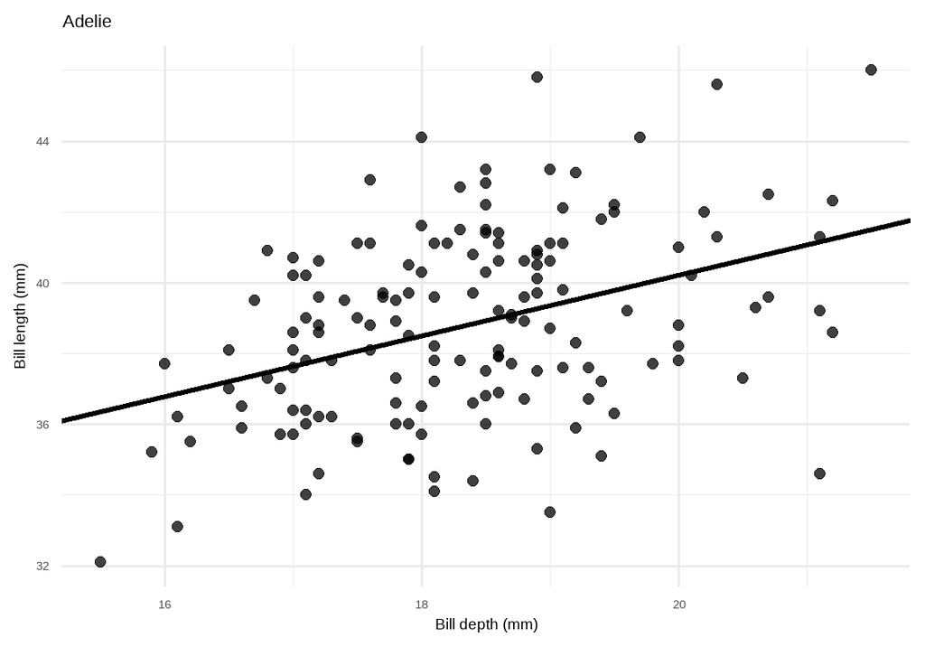

The pipeline ran, the graph records why, and the result is ready to use.

# Exercise 1: the default pipeline

## Inside generated `_targets.R`

```r
library(targets)

tar_option_set(
  packages = c("tibble")
)

tar_source()

list(
  tar_target(
    data,
    tibble(
      x = rnorm(100),
      y = rnorm(100)
    )
  ),
  tar_target(
    model,
    coefficients(lm(y ~ x, data = data))
  )
)
```

1. Load the pipeline infrastructure.
2. Set options shared by targets.
3. Source functions from `R/` when present.
4. Return the target list.

## Exercise 1, stage 1: a new targets project

**Work individually or with a neighbour.**

1. Create a blank RStudio Project named `targets-penguins` outside the lecture repository.
2. Create the default pipeline:

```r
targets::use_targets()
```

3. Open `_targets.R`. Find `library(targets)`, `tar_source()`, and the final `list()`.
4. Inspect the two example targets:

```r
targets::tar_manifest()
```

**Success:** the manifest lists `data` and `model`.

## Exercise 1, stage 2: build and inspect

1. Build the generated pipeline:

```r
targets::tar_make()
```

2. Run the same command again. What changes in the console output?
3. Inspect the completed pipeline:

```r
targets::tar_visnetwork()
```

**Success:** both runs finish without errors, and a two-node network appears. [Checkpoint 1](https://raw.githubusercontent.com/SSoQE/SSoQE-Reproducible_Analytical_Pipelines/main/Exercise_project_starter/Checkpoints/01_default_targets.R)

## Exercise 1 debrief

### First run

`tar_make()` builds `data`, then `model`.

### Second run

`tar_make()` skips both targets.

[interactive chart not shown]

# Building the penguin pipeline

## Functions and packages

```r
targets::tar_source("R/Functions")

targets::tar_option_set(
  packages = c(
    "dplyr",
    "ggplot2",
    "readr",
    "tidyr"
  )
)
```

`tar_source()`: load project functions.

`tar_option_set()`: declare packages for target processes.

[`tar_source()` reference](https://docs.ropensci.org/targets/reference/tar_source.html)

## A tracked file

```r
targets::tar_target(
  penguins_file,
  "Data/Input/penguins.csv",
  format = "file"
)
```

With `format = "file"`

Tracks the file contents.

[Files in targets](https://books.ropensci.org/targets/data.html)

## First targets

```r
targets::tar_target(
  penguins_raw,
  read_penguins(penguins_file)
),
targets::tar_target(
  penguins_clean,
  clean_penguins(penguins_raw)
),
```

```
flowchart LR
  F[penguins_file] --> R[penguins_raw] --> C[penguins_clean]
```

## Analysis targets

```r
targets::tar_target(selected_species, "Adelie"),
targets::tar_target(
  penguins_species,
  filter_penguins(penguins_clean, selected_species)
),
targets::tar_target(
  penguin_model,
  fit_penguin_model(penguins_species)
),
targets::tar_target(
  penguin_figure,
  plot_penguin_model(penguins_species, penguin_model)
),
```

## Pipeline inspection

```r
targets::tar_manifest()
```

Read every command.

```r
targets::tar_visnetwork()
```

Check every edge.

```
flowchart TB
  F[penguins_file] --> R[penguins_raw]
  R --> C[penguins_clean]
  C --> D[penguins_species]
  S[selected_species] --> D
  D --> M[penguin_model]
  D --> P[penguin_figure]
  M --> P
```

## Exercise 2, stage 1: get the prepared files

**Stay in your `targets-penguins` project.** Inspect the raw [`setup_exercise.R`](https://raw.githubusercontent.com/SSoQE/SSoQE-Reproducible_Analytical_Pipelines/main/setup_exercise.R), then run:

```r
source(paste0(
  "https://raw.githubusercontent.com/",
  "SSoQE/SSoQE-Reproducible_Analytical_",
  "Pipelines/main/setup_exercise.R"
))
```

Check that the bootstrap created local, editable files:

```r
list.files("R/Functions")
file.exists("Data/Input/penguins.csv")
```

**Success:** seven function files appear and the CSV check returns `TRUE`.

## Exercise 2: build and run

**With a partner.**

1. After the bootstrap, replace the generated example.
2. Source `R/Functions` and declare packages.
3. Add the seven targets from the preceding code slides.
4. Inspect with `tar_manifest()` and `tar_visnetwork()`.
5. Run twice, then read `penguin_figure`.

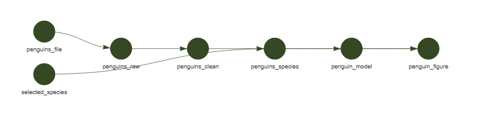

Expected `tar_visnetwork()` result after a successful build · dark green = up to date

## Exercise 2: support

**Success**

- The graph contains seven targets.
- The first `tar_make()` builds them.
- The second `tar_make()` skips them.
- `tar_read(penguin_figure)` shows an Adelie plot.

**Checkpoint:** [`Checkpoints/02_penguin_pipeline.R`](https://raw.githubusercontent.com/SSoQE/SSoQE-Reproducible_Analytical_Pipelines/main/Exercise_project_starter/Checkpoints/02_penguin_pipeline.R)

## Exercise 2 debrief

### First run

```
#> 7 completed
#> 0 skipped
```

Targets stores each returned value in `_targets/`.

### Second run

```
#> skipped pipeline
#> 7 skipped
```

Current code, inputs, and stored values agree.

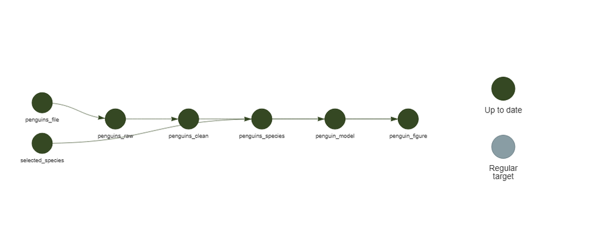

# When a pipeline changes

## A plot function changes

```r
ggplot2::geom_point(
  shape = 19,
  size = 2.2,
  alpha = 0.75
)
```

```r
ggplot2::geom_point(
  shape = 17,
  size = 2.2,
  alpha = 0.75
)
```

Which targets are now outdated?

## The graph marks work to update

```r
targets::tar_visnetwork()
```

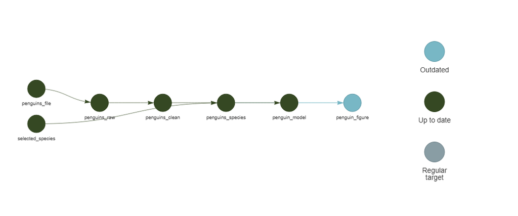

For names only: `tar_outdated()` returns `"penguin_figure"`.

## A cleaning function changes

Which targets become outdated?

```r
targets::tar_visnetwork()
```

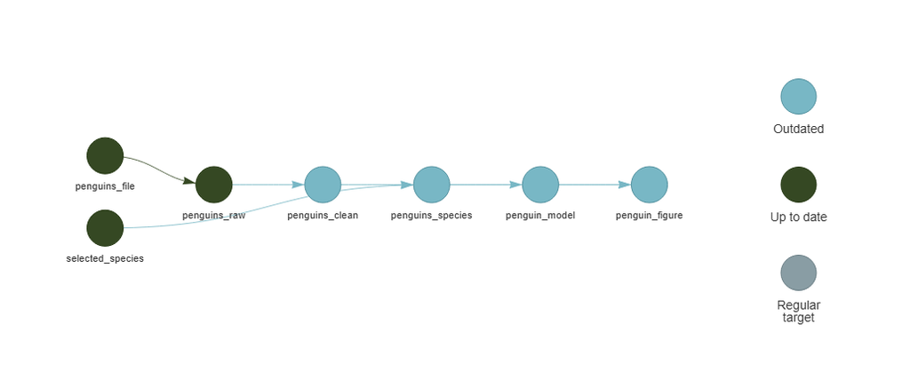

## An input file changes

Which targets become outdated?

```r
targets::tar_visnetwork()
```

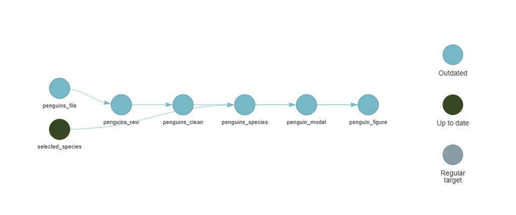

`selected_species` stays current: it does not depend on the CSV.

## A target fails

```
#> + penguin_model dispatched
#> ✖ penguin_model errored
#> ✖ errored pipeline
#> Error: object 'bill_depth_mm' not found
```

The completed upstream targets stay in the cache.

## The recorded error

```r
targets::tar_meta(
  fields = error,
  complete_only = TRUE
)
```

```
#> # A tibble: 1 × 2
#>   name           error
#>   <chr>          <chr>
#> 1 penguin_model  object 'bill_depth_mm' not found
```

[Official debugging guide](https://books.ropensci.org/targets/debugging.html)

## Interactive debugging

```r
targets::tar_load_globals()
targets::tar_load(penguins_species)

fit_penguin_model(penguins_species)
```

1. Reproduce the error outside the pipeline.
2. Fix the function.
3. Run `tar_make()` again.

# Exercise 3: change and extend

## Exercise 3: change and extend

**With a partner.**

1. In `R/Functions/plot_penguin_model.R`, change `shape = 19`.
2. Write down your prediction, then run `tar_outdated()`.
3. Rebuild and confirm that upstream targets skip.
4. Add `tar_target(penguin_summary, summarise_penguins(penguins_species))`.
5. Inspect, build, and read the new target.

## Exercise 3: support

**Success**

- Your outdated set matches your written prediction.
- The graph contains `penguin_summary`.
- `tar_read(penguin_summary)` returns a table.
- A final `tar_make()` skips all work.

**Checkpoint:** `Checkpoints/03_extended_pipeline.R`

## Exercise 3 debrief

```
flowchart TB
  F[file] --> R[raw] --> C[clean] --> D[data]
  S[species] --> D --> M[model]
  D --> P[figure]
  M --> P
  D --> A[new summary]
  style A fill:#A1C3B3,color:#1F2937
```

**Skipped:** current upstream work

**Rebuilt:** changed figure

**Built:** new summary

# More complex pipelines

## One analysis per species

A list can hold one dataset per species:

```r
penguins_by_species <-
  split_penguins(penguins_clean)
```

`targets` can create one model target for each list element:

```r
targets::tar_target(
  penguin_model,
  fit_penguin_model(penguins_by_species),
  pattern = map(penguins_by_species),
  iteration = "list"
)
```

## Dynamic branches

```
flowchart TB
  C[penguins_clean] --> B[penguins_by_species]
  B --> A[Adelie model]
  B --> H[Chinstrap model]
  B --> G[Gentoo model]
  A --> AP[Adelie figure]
  H --> HP[Chinstrap figure]
  G --> GP[Gentoo figure]
```

Branches can run independently and in parallel with workers.

[Dynamic branching chapter](https://books.ropensci.org/targets/dynamic.html)

# Outro

## Start again tomorrow

### 4 minutes

[Official video and example project](https://docs.ropensci.org/targets/#get-started-in-4-minutes)

Replay the basic lifecycle.

### One tutorial

[Official walkthrough](https://books.ropensci.org/targets/walkthrough.html)

Build another small pipeline carefully.

### One complete course

[Carpentries Incubator workshop](https://carpentries-incubator.github.io/targets-workshop/)

Guided practice from setup to reports. The lesson currently has pre-alpha status.

### The bigger picture

[Reproducible analytical pipelines with R](https://raps-with-r.dev/targets.html)

Connect targets with functions, tests, environments, and reports.

## Where do I look?

| My question | Best starting point |
| --- | --- |
| Function arguments? | [Function reference](https://docs.ropensci.org/targets/reference/index.html) |
| Pipeline failed? | [Debugging guide](https://books.ropensci.org/targets/debugging.html) |
| Ask for help? | [Help guide](https://books.ropensci.org/targets/help.html) |
| Repeat an analysis? | [Dynamic branching](https://books.ropensci.org/targets/dynamic.html) |
| Render a Quarto report? | [Reports chapter](https://books.ropensci.org/targets/literate-programming.html) |
| Extension packages? | [R Targetopia](https://wlandau.github.io/targetopia/) |

## About me

[figure not shown]

[figure not shown]

Ondřej Mottl

Assistant Professor of Plant Ecology at [Charles University](https://cuni.cz/UK-1.html)

Head of the [Laboratory of Quantitative Ecology](https://ondrejmottl.github.io/lab/about_the_lab.html)

- 📧 Ondrej.mottl(at)gmail.com
- 🦋 [Bluesky](https://bsky.app/profile/ondrejmottl.bsky.social)
- 🐱 [GitHub](https://github.com/OndrejMottl)
- 🆔 [ORCID](https://orcid.org/0000-0002-9796-5081)
- 🌐 [Personal webpage](https://ondrejmottl.github.io/)